# C3(1)TAg mouse model dataset visual analysis

Angel F. Alvarado Velez

2025-07-18

## What is a C3(1)TAg mouse model?

The C3(1)TAg mouse model is a transgenic mouse model used to study mammary cancer. It’s characterized by the expression of the SV40 large T-antigen under the control of the C3(1) gene promoter, leading to tumor development in mammary glands and prostate in male mice. This model is particularly useful for studying basal-like triple-negative breast cancer and the role of obesity in breast cancer development.

**1. First we load the necessary libraries**

```r
library(Seurat)
library(ggplot2)
library(Seurat)
library(ggplot2)
library(dplyr)
```

**2. Run commands to reduce differentiation**

```r
seuratObj <- RunPCA(seuratObj)
seuratObj <- NormalizeData(seuratObj)
seuratObj <- FindVariableFeatures(seuratObj)
seuratObj <- ScaleData(seuratObj)
seuratObj <- RunUMAP(seuratObj, dims = 1:10)
```

**Both UMAP & PCA simplify complex data by reducing the number of variables while retaining important information**

## Visualizations

**3. Create UMAP plot side-by-side with annotations for stromalClass and celltype**

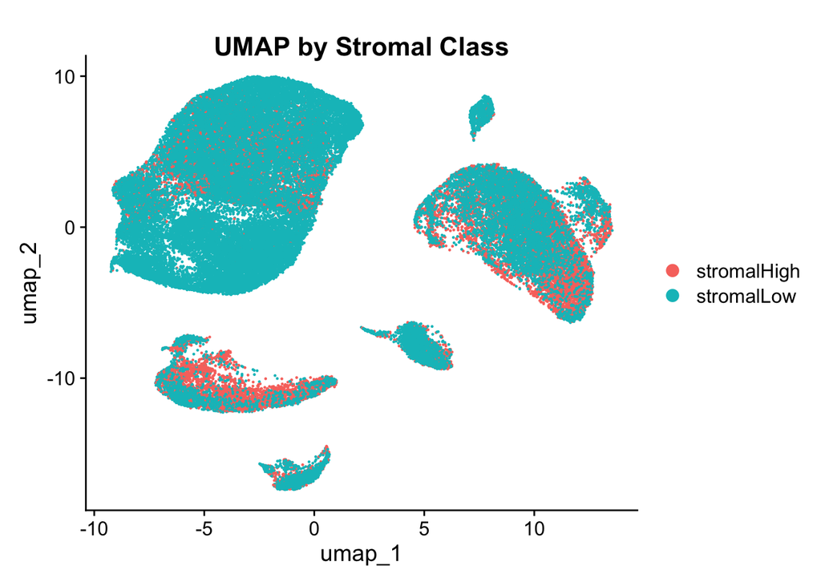

```r
DimPlot(seuratObj, reduction = "umap", group.by = "stromalClass") +
  ggtitle("UMAP by Stromal Class") +
  theme(plot.title = element_text(hjust = 0.5, vjust = -2))
```

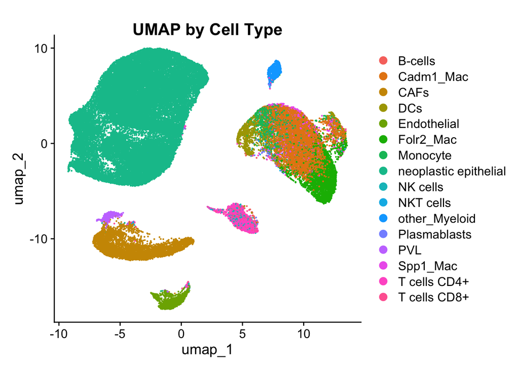

```r
DimPlot(seuratObj, reduction = "umap", group.by = "celltype") +
  ggtitle("UMAP by Cell Type") +
  theme(plot.title = element_text(hjust = 0.5, vjust = -2))
```

**4. Now, we use FeaturePlot in order to create UMAP projections showing the expressions of 3 genes:**

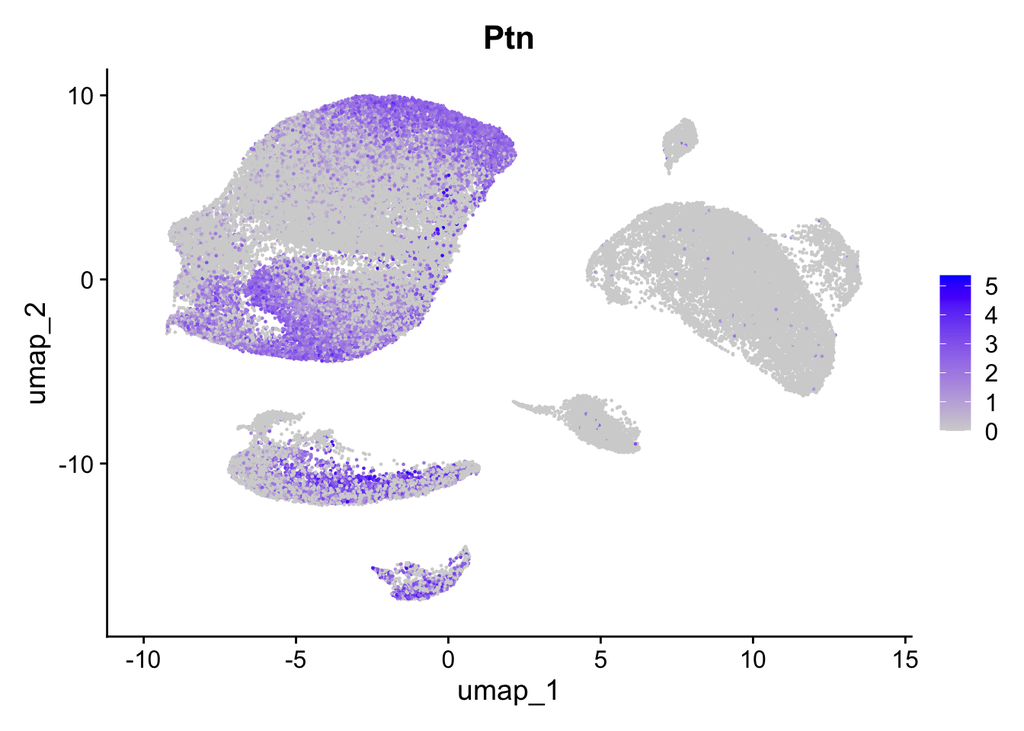

```r
FeaturePlot(seuratObj, features = "Ptn", reduction = "umap")
```

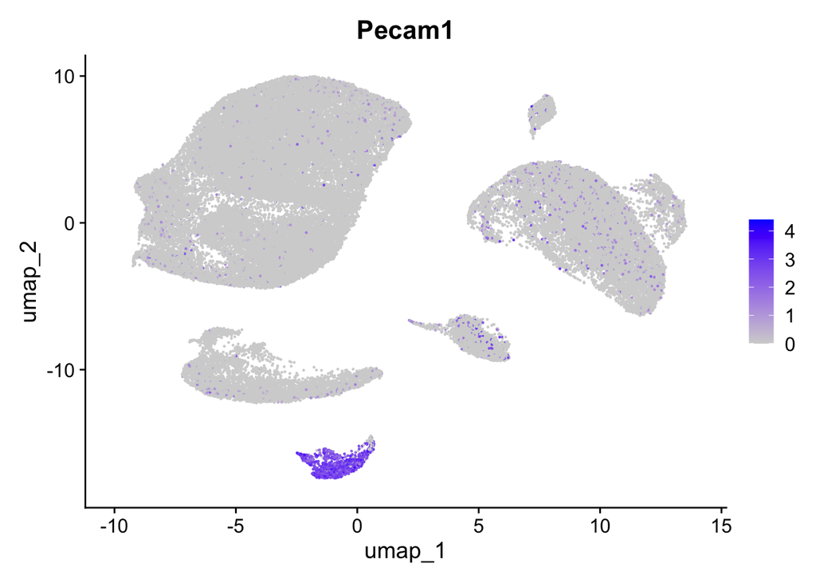

```r
FeaturePlot(seuratObj,features = "Pecam1", reduction = "umap")
```

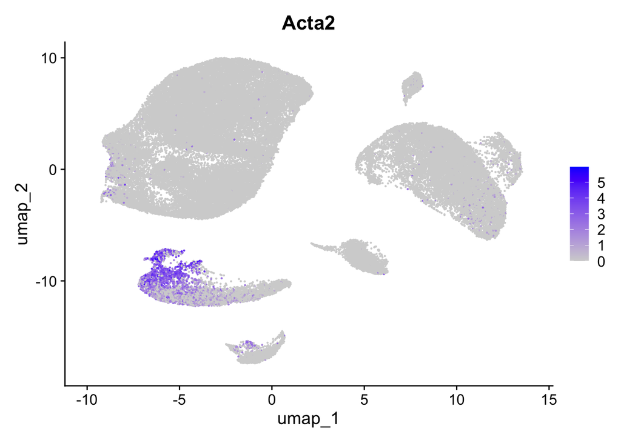

```r
FeaturePlot(seuratObj, features = "Acta2", reduction = "umap")
```

**5, Create a Vln & DotPlot to show distributions of gene expression levels across cell types (Ptn,Acta2 & Pecam1)**

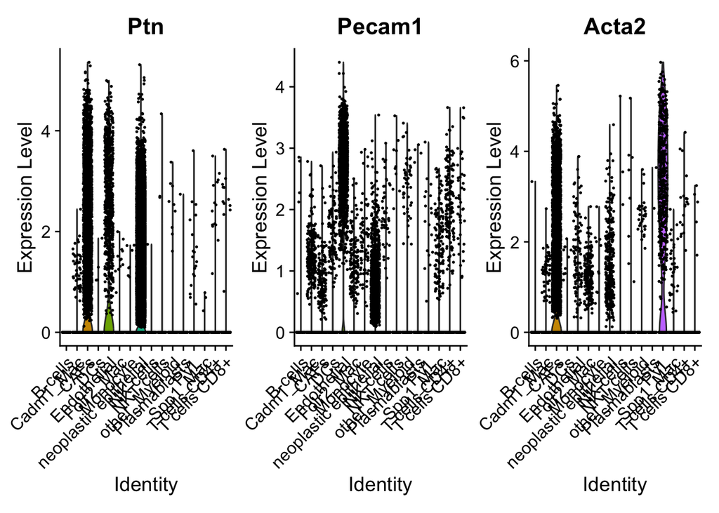

```r
VlnPlot(seuratObj, features = c("Ptn", "Pecam1", "Acta2"), group.by = "celltype", pt.size =0.3)
```

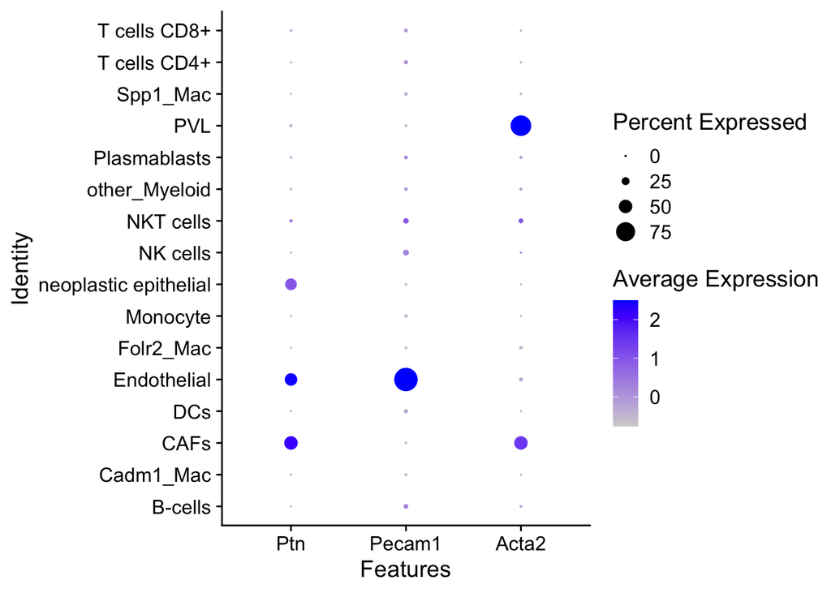

```r
DotPlot(seuratObj, features = c("Ptn", "Pecam1", "Acta2"), group.by = "celltype")
```

**6. Identify marker genes, filter table to top 5 gene markers for each cell type & rearrange table**

```r
markers <- FindAllMarkers(seuratObj)
top_markers <- markers %>%
  group_by(cluster) %>%
  top_n(5, wt = avg_log2FC) %>%
  arrange(cluster, desc(avg_log2FC))
top_markers <- top_markers %>%
  select(c(6, 7, everything()))  # Move columns 6 and 7 to the front**
```

**7. Convert cell type to a factor & drop unused levels**

```r
seuratObj$celltype <- factor(seuratObj$celltype)
seuratObj$celltype <- droplevels(seuratObj$celltype)
```

**8. Create DotPlot showing expression of top cell type marker genes**

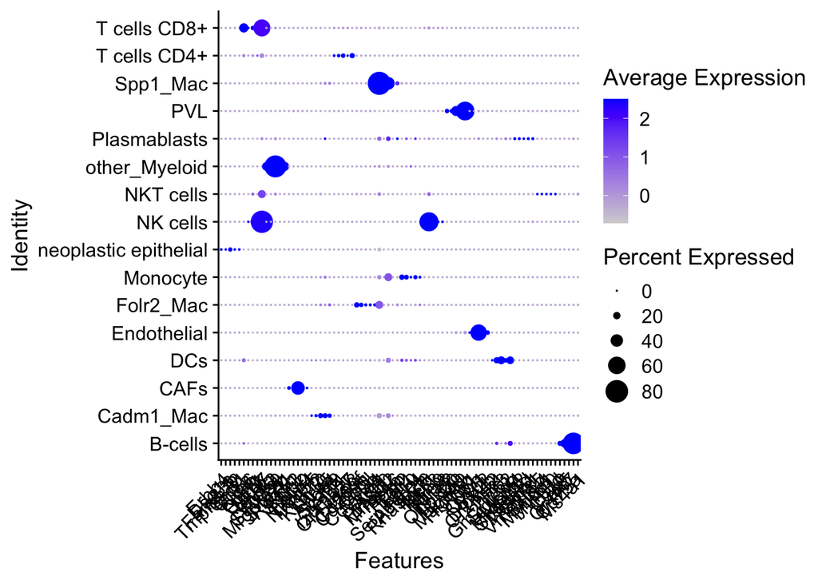